# 2_analyse_CCVR05

Tom Beesley

06/06/2020

The study consisted of three parts: a training, a contextual cueing paradigm, and an awareness test.

The main task was divided into two phases. In the first ‘learning’ phase, a 2 x 2 x 10 within-subject design was applied, with a factor of Target Location, which referred to a hemisphere on which the target was located (near vs. far), Configuration, which was either repeated across trials or newly generated for every trial (repeated vs. random), and Block (1-10).

The second ‘manipulation’ phase consisted of a 2x3x8 within-subject design, with a factor of Target Location (near vs. far), Configuration (random vs. non-switched vs. switched) and Block (1-8). Three types of configurations were presented: 1) random, which were newly-generated for every trial, 2) non-switched, which were identical to the repeated configurations from the first phase, 3) switched, which resembled the repeated configurations from the first phase with that difference, that the near hemisphere now featured distractors that previously appeared on the far hemisphere, while the far hemisphere now presented distractors that in the first phase were shown on the near hemisphere. While all distractors changed their depth, the target remained on its original hemisphere.

A single block contained 16 trials which in total gave 160 trials in the learning phase and 128 trials in the manipulation phase. Out of these 16 trials, eight configurations were generated randomly, whilst the other eight were repeated. In the second phase, four of these eight repeated configurations were subjected to a depth swap.

Summary statistics for RTs and number of responses made:

| mean_RT_mean | 0.97 |
| --- | --- |
| perc_Timeouts_mean | 0.12 |
| mean_Extra_Resp_mean | 0.75 |
| perc_Rs_Over1_mean | 0.31 |
| perc_Rs_Over2_mean | 0.14 |
| mean_RT_sd | 0.03 |
| perc_Timeouts_sd | 0.04 |
| mean_Extra_Resp_sd | 0.67 |
| perc_Rs_Over1_sd | 0.14 |
| perc_Rs_Over2_sd | 0.11 |

Data processing: trials which led to timeouts, and trials that had more than one additional responses (i.e., up to 2 responses allowed) were removed. Following this, RTs greater or less than 2.5 SDs from the participant mean RT were removed. On average this resulted in the loss of 19.4% of trials. Normalised RT was computed in order to create within-subject error bars in all plots.

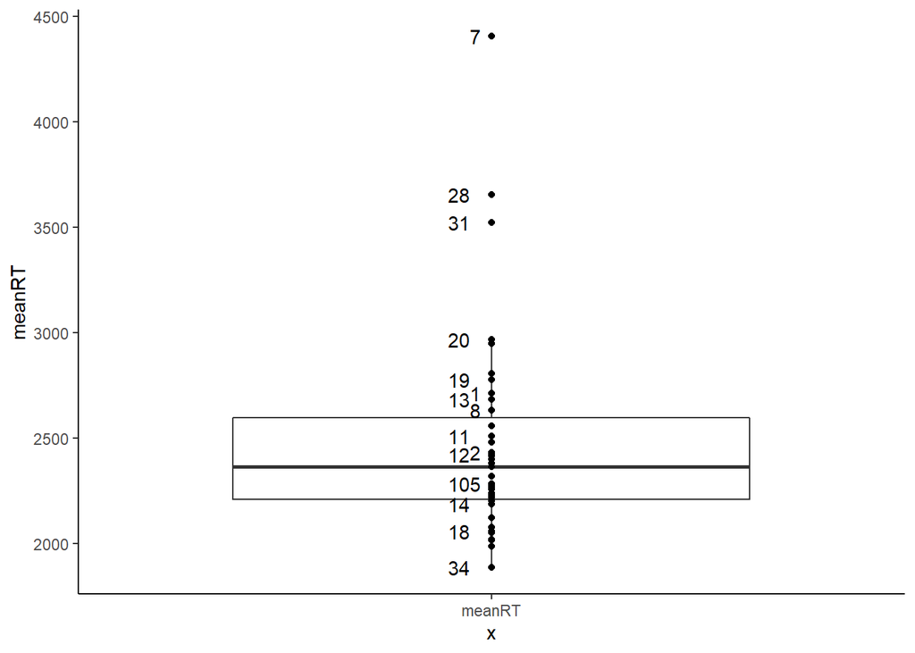

Mean RTs for each participant were computed and the mean across the sample was 2476 ms (SD = 493). 1 participants [7] produced means that were more than 2.5 SDs above the mean of the sample, and were removed from further analysis.

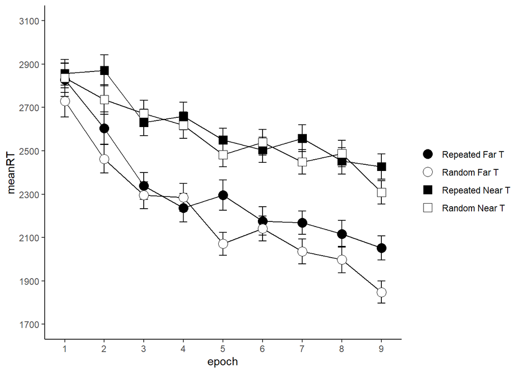

```
## Anova Table (Type 3 tests)
##
## Response: meanRT
##                Effect           df       MSE         F   ges p.value
## 1                  TT        1, 37 167474.92   8.02 **  .003    .007
## 2          targ_depth        1, 37 822771.48 48.79 ***  .084   <.001
## 3               epoch 5.20, 192.49 365592.06 28.46 ***  .110   <.001
## 4       TT:targ_depth        1, 37 178475.47      1.55 <.001    .221
## 5            TT:epoch 5.88, 217.69 197050.25      1.40  .004    .216
## 6    targ_depth:epoch 5.63, 208.41 212483.45    2.79 *  .008    .014
## 7 TT:targ_depth:epoch 6.41, 237.31 153773.35      0.73  .002    .635
## ---
## Signif. codes:  0 '***' 0.001 '**' 0.01 '*' 0.05 '+' 0.1 ' ' 1
##
## Sphericity correction method: GG
```

```
##
##  Paired t-test
##
## data:  meanRT by TT
## t = -1.6252, df = 37, p-value = 0.1126
## alternative hypothesis: true difference in means is not equal to 0
## 95 percent confidence interval:
##  -185.5451   20.3792
## sample estimates:
## mean of the differences
##               -82.58294
```

The effect is not present in the Far condition…

```
##
##  Paired t-test
##
## data:  meanRT by TT
## t = -1.1843, df = 37, p-value = 0.2438
## alternative hypothesis: true difference in means is not equal to 0
## 95 percent confidence interval:
##  -133.01206   34.87938
## sample estimates:
## mean of the differences
##               -49.06634
```

…or the near condition.

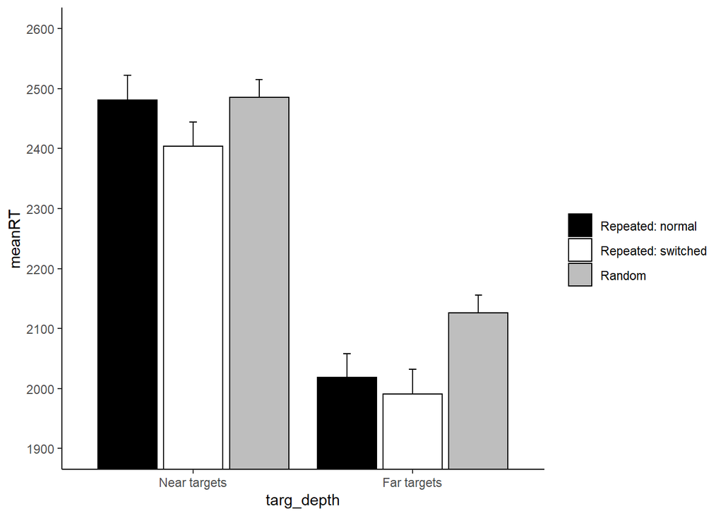

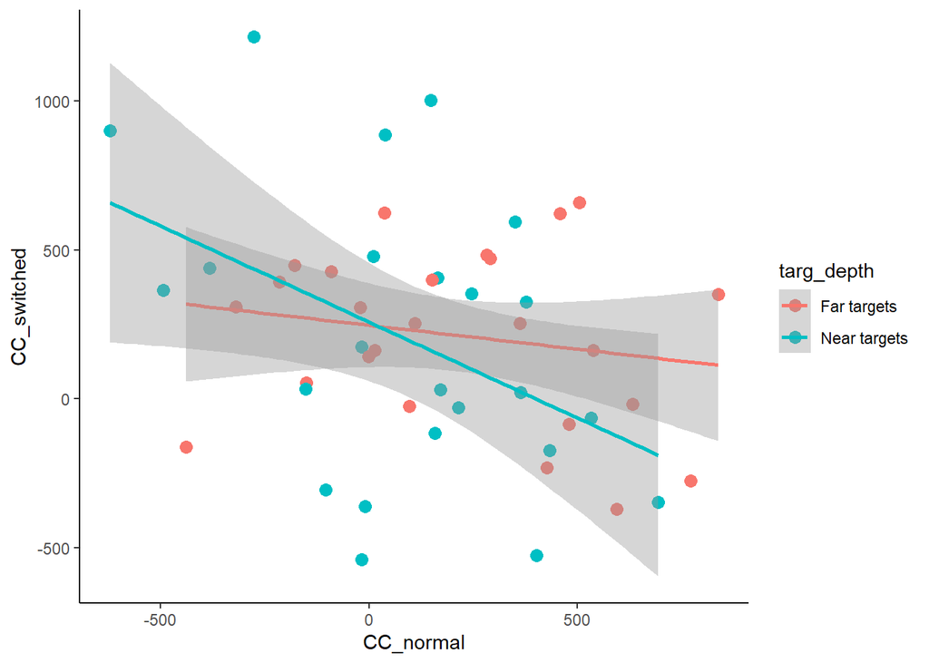

```
##
##  Pearson's product-moment correlation
##
## data:  .$CC_normal and .$CC_switched
## t = -2.2503, df = 47, p-value = 0.02915
## alternative hypothesis: true correlation is not equal to 0
## 95 percent confidence interval:
##  -0.54524576 -0.03361604
## sample estimates:
##        cor
## -0.3118647
```